# Constructing and Analyzing DAGs in dagitty and ggdag_demo

```r
# print conditional independences
impliedConditionalIndependencies(richness_dag)
```

```
## Clm_ _||_ D__R
## Clm_ _||_ NPKT
## Clm_ _||_ Ol__
## Clm_ _||_ SF_0 | Ndp_
## Clm_ _||_ lvs_
## Clm_ _||_ ps_0
## D__R _||_ NPKT
## D__R _||_ Nt_0 | Clm_, SF_0, lvs_, ps_0
## D__R _||_ Nt_0 | Ndp_, SF_0, lvs_, ps_0
## D__R _||_ Nt_0 | Ol__, lvs_, ps_0
## D__R _||_ Ndp_
## D__R _||_ SF_0 | Ol__, lvs_, ps_0
## Ex_0 _||_ NPKT
## Ex_0 _||_ Nt_0 | Clm_, SF_0, lvs_, ps_0
## Ex_0 _||_ Ol__ | D__R, Ndp_, SF_0, lvs_, ps_0
## NPKT _||_ Nt_0
## NPKT _||_ Ndp_
## NPKT _||_ Ol__
## NPKT _||_ SF_0
## NPKT _||_ lvs_
## NPKT _||_ ps_0
## Nt_0 _||_ Ndp_ | Clm_, SF_0, lvs_, ps_0
## Nt_0 _||_ Ol__ | Ndp_, SF_0, lvs_, ps_0
## Nt_0 _||_ Ol__ | Clm_, SF_0, lvs_, ps_0
## Ndp_ _||_ Ol__
## Ndp_ _||_ lvs_
## Ndp_ _||_ ps_0
## Ol__ _||_ lvs_ | D__R
## Ol__ _||_ ps_0 | D__R
```

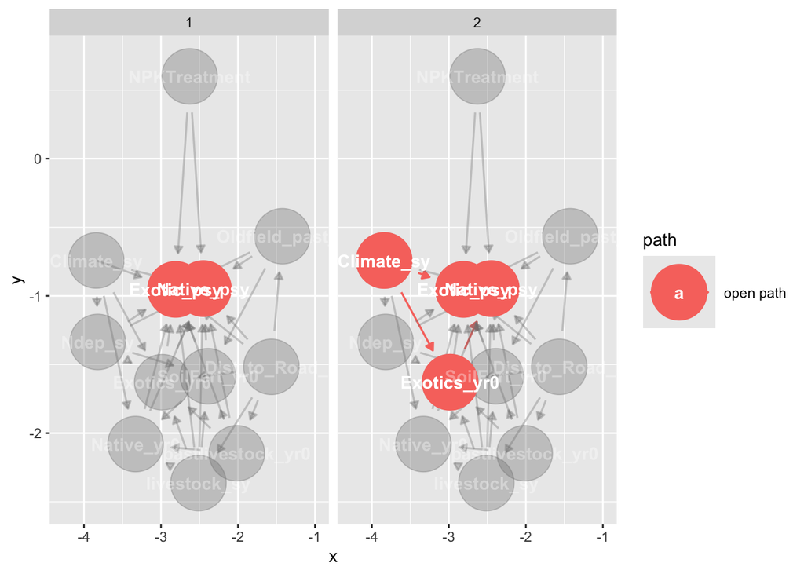

```r
# Now, lets plot the open paths
ggdag_paths(richness_dag, shadow = TRUE)
```

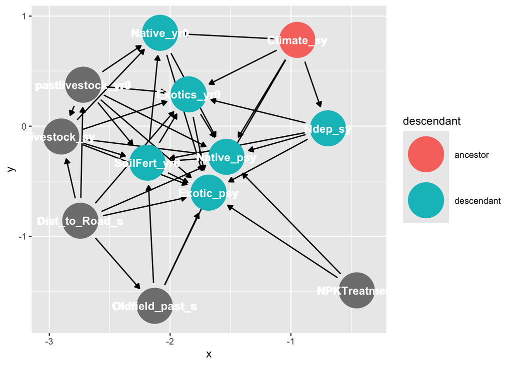

```r
#to identify descendants
ggdag_descendants(richness_dag, "Climate_sy")
```

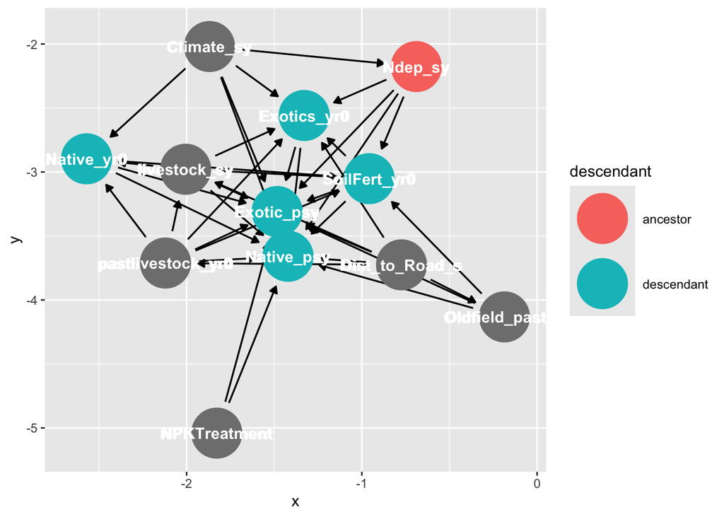

```r
ggdag_descendants(richness_dag, "Ndep_sy")
```

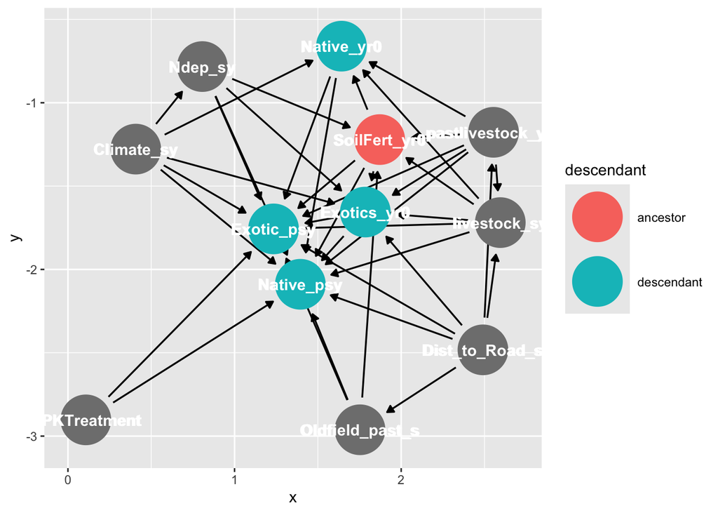

```r
ggdag_descendants(richness_dag, "SoilFert_yr0")
```

```r
#identify the paths that need to be adjusted for - because we have specified the exposure to be invasive abundance and outcome to be richness, we are looking at the direct effect (not the mediated effect), so the direct and total will be thed same here:
adjustmentSets(richness_dag, effect = "direct")
```

```
## { Climate_sy, Dist_to_Road_s, Exotics_yr0, NPKTreatment, Native_yr0,
##   Ndep_sy, Oldfield_past_s, SoilFert_yr0, livestock_sy,
##   pastlivestock_yr0 }
```

```r
adjustmentSets(richness_dag, effect = "total")
```

```
## { Climate_sy, Dist_to_Road_s, Exotics_yr0, NPKTreatment, Native_yr0,
##   Ndep_sy, Oldfield_past_s, SoilFert_yr0, livestock_sy,
##   pastlivestock_yr0 }
```

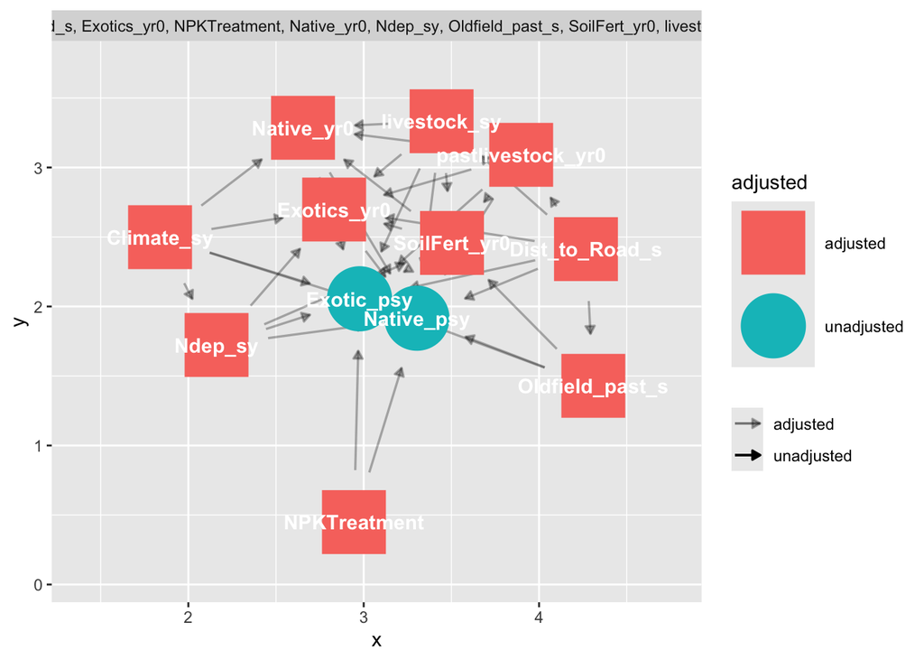

```r
#Let's plot the identified the adjustment set to meet the backdoor criterion
ggdag_adjustment_set(richness_dag, shadow = TRUE)
```

Let’s compare the above with analyzing the treatment effect, which was randomized. You can see we don’t need to adjust to estimate the treatment effect on richness.

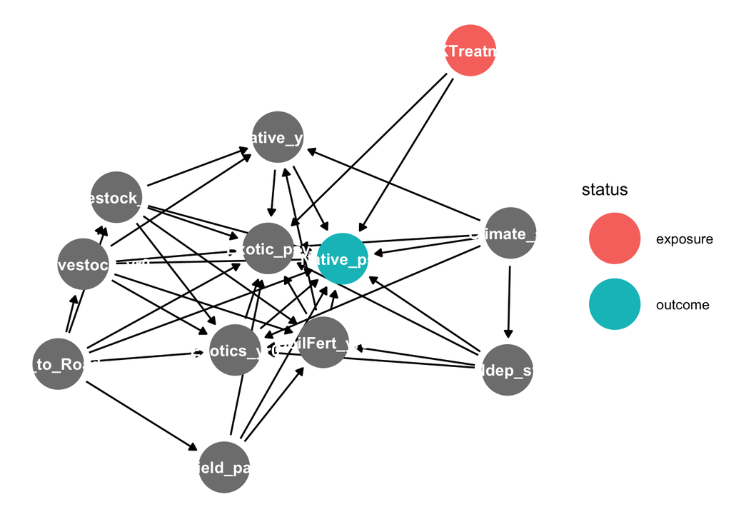

```r
NPK_dag <- dagify(Native_psy ~ Exotic_psy + NPKTreatment + Exotics_yr0 + Native_yr0 + Ndep_sy + Climate_sy + SoilFert_yr0 +  livestock_sy + Dist_to_Road_s + Oldfield_past_s + pastlivestock_yr0,
 Exotic_psy ~  NPKTreatment + Exotics_yr0 + Native_yr0 + Ndep_sy + Climate_sy + SoilFert_yr0 +
 livestock_sy + Dist_to_Road_s + Oldfield_past_s + pastlivestock_yr0,
 Ndep_sy ~  Climate_sy,
 Exotics_yr0 ~ Climate_sy + Ndep_sy + pastlivestock_yr0 + livestock_sy + Dist_to_Road_s + SoilFert_yr0,
 Native_yr0 ~ Climate_sy + pastlivestock_yr0 + livestock_sy + SoilFert_yr0,
   SoilFert_yr0 ~ Ndep_sy + Oldfield_past_s +  livestock_sy +  pastlivestock_yr0,
  Oldfield_past_s  ~ Dist_to_Road_s,
  livestock_sy  ~ pastlivestock_yr0 + Dist_to_Road_s,
   pastlivestock_yr0 ~ Dist_to_Road_s,
  exposure = "NPKTreatment",
  outcome = "Native_psy",
 labels = c(outcome = "richness",
           exposure = "NPKTreatment"))

ggdag_status(NPK_dag,
             use_labels = "label",
             text = TRUE,
             label_alpha = 0.5) + theme_dag()
```

```r
adjustmentSets(NPK_dag, effect = "total")
```

```
##  {}
```

# Your turn to practice.

## Let’s plot the Arif et al. (2022) Coral Reef Example for more practice!

You’ll note, to analyze the DAG, you’ll need to specify the exposure and the outcome. To look at a bunch of different relationships, this needs to be done one by one to avoid a “causal salad” in the amazing terms of Arif et al.

*You can practice writing code to do this for a given exposure and outcome, modifying the code above for this example below!*

```
## Plot coordinates for graph not supplied! Generating coordinates, see ?coordinates for how to set your own.
```

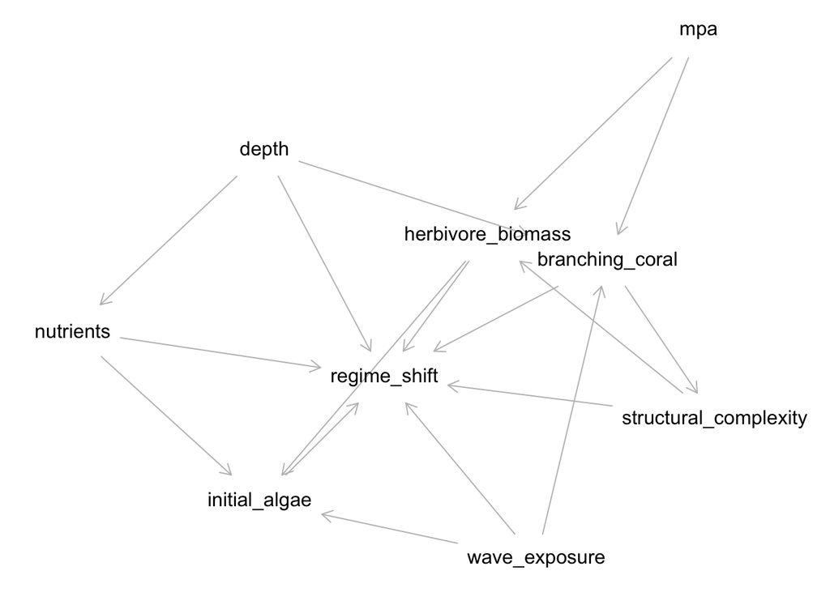

```r
seychelles <- dagify(
  regime_shift ~ initial_algae + wave_exposure + herbivore_biomass + depth + nutrients + branching_coral + structural_complexity,
  initial_algae ~ wave_exposure + herbivore_biomass + nutrients,
  herbivore_biomass ~ mpa + structural_complexity,
  nutrients ~ depth,
  branching_coral ~ mpa + depth + wave_exposure,
  structural_complexity ~ branching_coral
)

plot(seychelles)
```

Your turn – pick an exposure and outcome and go!

To consider other sources of bias (collider, omitted variable bias, etc) see https://lfoswald.github.io/2021-spring-stats2/materials/session-4/04-online-tutorial/